None

# Second Order Motorcycle/Bicycle Model

[Alexander Brown, Ph. D](https://sites.lafayette.edu/brownaa)

## Introduction

The **linear** second-order ordinary differential equation model we will develop here uses many of the same assumptions as Astrom ( 2007). These include no longitudinal acceleration, symmetry of the bike in the XZ plane, insignificant mass of the front frame (including fork and wheel), knife-edged tires, no tire slip, insignificant gyroscopic effects from the spinning wheels, and small perturbations from steer and roll angles of zero (straight running). The model developed here is perhaps the simplest model of bicycle and motorcycle dynamics possible that captures their dynamics well enough for the purposes of control design. If you have already gone through this model and you are ready for something more complex that can explain the self-stabilization dynamics of bicycles and motorcycles, try [this notebook](https://alexanderallenbrown.github.com/motorcycle_model_fourth) instead.

Before you read this notebook, you should start with This one because the derivation below relies on LaGrange's method.

## What is this model good for?

This model explains the relationship between the *steer angle* and *steer rate* of a bicycle/motorcycle's front wheel and its motion in the roll direction. Using steer angle as a system input implies that the vehicle's steer angle is driven by an infinite-power source that can dictate its angle omnipotently... this is not a good assumption for most situations, given that we know that bicycles and motorcycles are stable under hands-free riding for some speeds. However, for a *self-driving* motorcycle or bicycle that uses a "servo" to control steer angle, this model is not bad. The catch is that the model is *never* stable without active input from the rider, because this model does not capture a single-track vehicle's ability to steer itself (which they are, in fact, capable of).

## Coordinates and variables

The coordinate system used for our bicycle and associated dimensions are presented below in Figure 1.

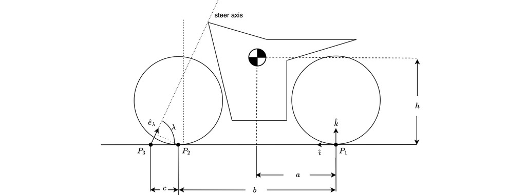

**Figure 1. Coordinates and dimensions**

### Lengths, velocities, and angles

- $b$ is the vehicle's wheelbase, the distance between the rear tire contact point $P_1$ and the front tire contact point $P_2$
- $a$ is the $x$ distance from the rear tire contact point to the center of mass of the rear frame (inclusive of the rear tire's contribution, if any)
- $c$ is the "trail" or the "ground trail," the distance between the intersection of the steer axis with the ground ($P_3$) and the front tire contact patch $P_2$.
- $h$ is the height ($\hat{k}$-direction) of the vehicle's center of mass above the ground plane when the bike is upright.
- $\lambda$ is the inclination angle of the steering axis above the negative $\hat{\imath}$ axis.
- $\vec{\delta} = \delta\hat{e}_\lambda$ is the vector representation of the scalar steering angle $\delta$ about the steer axis, which is defined by the unit vector $\hat{e}_\lambda$
- $U$ is the bike's constant forward speed.

### Inertial parameters

- $m$ is the mass of the vehicle. We assume in this notebook that the vehicle's mass is sufficiently concentrated near its C.G. to make the assumption that it can be represented as a point mass.

## Kinematics of Motorcycle Turning

Before we get into the derivation of the motorcycle's dynamics, we need to understand how the "roll without slip" assumptions concerning the tires of the vehicle leads to a very special relationship between steer angle $\delta$ and the vehicle's "yaw rate" or angular velocity about the $\hat{K}$ direction, or the gravitational direction (this does not lean with the vehicle, if applicable).

Consider a two-wheeled vehicle navigating a turn at (relatively) low speeds, such that both of its wheels are moving (rolling) forwards relative to their respective headings, and not sliding laterally. The front wheel is steering about the gravitational ($\hat{K}$) direction, with an ISO standard, right-handed coordinate system fixed to the vehicle's rear wheel such that the $\hat{I}$ direction points forwards and the $\hat{J}$ direction points left. This setup is shown below. Note the use of capital letters for these coordinate directions. This is to indicate that while this is a vehicle-fixed coordinate system, the coordinate system does not *lean* with the vehicle as it rolls.

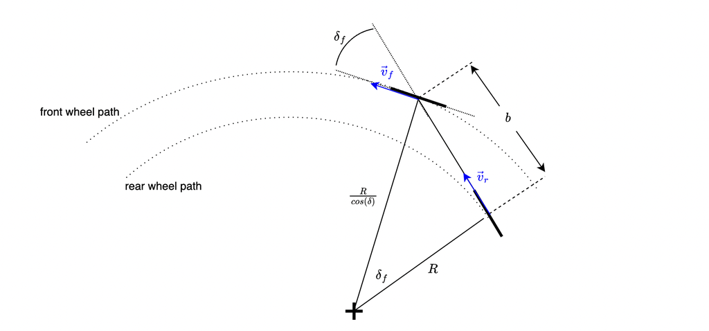

### The Vehicle's Instantaneous Center of Rotation (Turn Center)

The front wheel of the vehicle is steered at an angle $\delta_f$ about the $\hat{K}$ direction, so the front wheel's velocity vector is oriented differently than the rear wheel's velocity vector. If the vehicle is traveling at a forward speed of $U\hat{I}$, and the wheels roll without slip on the ground, then both wheels have a velocity with a *magnitude* of $U$, even though they are pointed in different directions.

When two velocity vectors on a rigid body are misaligned, it means the rigid body *rotates* as well as translates. If a rigid body rotates, it means that there is a point *somewhere* about which it *only* rotates. This point is called the *[instantaneous center of rotation](https://en.wikipedia.org/wiki/Instant_centre_of_rotation)* (ICR). For a vehicle, it's easy to conceptualize this point as "the center of the turn" the vehicle is navigating.

To find the ICR for a rigid body, we realize that if we consider the velocity of any point $p$ on the body with respect to a non-moving (ground) reference, we can write:

$$\vec{v}_p = \vec{\omega}\times\vec{r}_{p/IC},$$

where $\vec{r}_{p/IC}$ is the position of the point $p$ with respect to the instantaneous center, and $\vec{\omega}$ is the angular velocity of the rigid body. In top view, neglecting the vehicle's roll and pitch motion, this is the vehicle's *yaw rate* $\vec{\omega} = \dot{\psi}\hat{K}$. Then finding the ICR is as simple as substituting $\vec{v}_r = U\hat{I}$ and $\vec{\omega} = \dot{\psi}\hat{K}$ into the equation above.

That is an algebraically feasible way to solve for the ICR vector. However, the fact that *any* point on the vehicle will have velocity $\vec{v}_p$ as described above as a pure cross product of angular velocity and a position vector means that every point $p$ on on the vehicle will have a velocity that is *perpendicular* to the vector $\vec{r}_{p/IC}$. This means that a quick way to find the ICR is to draw lines perpendicular to both $\vec{v}_f$ and $\vec{v}_r$, and note where they meet. This point is the ICR!

### Relating $\delta_f$ to turn radius

If we define the vector $\vec{R}$ as the vector from the ICR to the rear wheel, describing the radius of the curved path traced by the rear wheel when the vehicle steers with $\delta_f$, then we can use right triangles to determine how that vector's length, $R$, and the steer angle $\delta_f$ are related.

Looking at the right triangle formed by the rear wheel contact, the front wheel contact, and the turn center in the figure above, we could write:

$$\tan \delta_f = \frac{b}{R}$$

If we assume that $\delta_f$ is a small angle, as we usually can, given that vehicle steering angles are almost less than $20^\circ$, we can approximate $\tan\delta_f = \frac{\sin \delta}{\cos \delta} \approx \frac{\delta_f}{1} = \delta_f$. Doing so allows us to solve for the turn radius $R$:

$$R = \frac{b}{\delta_f}$$

### Relating turn radius to yaw rate

The simplest way to do this is using the [arc length formula](https://www.cuemath.com/geometry/arc-length/). We know that the length $s$ along an arc can be written:

$$s = R\theta$$

where $\theta$ is the angle of an arc in radians, and $R$ is the arc's radius. For us, we could write the arc length formula for the vehicle's change in yaw angle $\Delta \psi$ corresponding with some forward motion of the vehicle:

$$\Delta S = R \Delta \psi$$

Then, looking at this change over a change in time $\Delta t$ and shrinking the change in time to zero, we see that we are taking the derivative of the arc length formula:

$$\dot{S} = R \dot{\psi}$$

Now, we remember that our velocity along the curve is simply the vehicle's forward velocity $U$, and we can write:

$$ U = R\dot{\psi}$$

### Relating steer angle to yaw rate

With the relationship between steering and turn radius, along with the relationship between turn radius and yaw rate, we can compute the yaw rate that results from a particular steering angle by rearranging the equations.

$$\dot{\psi} = \frac{U \delta_f}{b}$$

If we're studying a motorcycle or bicycle, we know that the "effective" steering angle on the ground plane for the bike is the $\hat{K}$-component of the true steering angle. Using the motorcycle coordinate system defined above, but once again using a coordinate system that does not roll with the bike, we can see that when the vehicle is steered about the $\hat{e}_\lambda$ axis, we can write:

$$\vec{\delta} = \delta \hat{e}\lambda = \delta\left(-\cos \lambda \hat{\imath} + \sin \lambda \hat{k}\right)$$

The $\hat{k}$-component of this vector is our "effective" steering angle $\delta_f$:

$$\delta_f = \vec{\delta}\cdot\hat{k} = \delta \sin \lambda$$

Substituting this in to our equation for yaw rate, we find that:

$$\dot{\psi} = \frac{U\sin \lambda}{b} \delta$$

Note that there *are* also contributions to yaw rate that come from *steer rate* or $\dot{\delta}$ but we will ignore those as "too small to matter" for the purposes of this simple model.

## The LaGrangian

If you have taken my [ES103](https://alexanderallenbrown.github.io/ES103_SP23_Students/) course, LaGrange's method is a fairly manageable next step in your tool box for developing dynamic models of mechanical systems. An introduction to the method and its relationship to the methods presented in ES103 is given here.

LaGrange's method for developing a system's equations of motion requires the "LaGrangian," or the difference between a system's kinetic and potential energy:

\begin{equation} L \equiv T - V \end{equation}

Where $T$ is a system's kinetic energy and $V$ is the system's potential energy, all defined in terms of the system's independent 'generalized coordinates.' For our system, the bike is permitted to roll about its local $x$-axis $\hat{\imath}$, which moves both the front and rear frames together. It is also permitted to "yaw" about the gravitational axis, and the steered frame (front frame) can rotate about the steering axis.

In order to begin our derivation, we need expressions for both the kinetic and potential energy of our vehicle.

## Kinetic Energy of the vehicle

To find the kinetic energy of the vehicle, we first need to find the velocity of its center of mass, since kinetic energy can be written:

\begin{equation} T_r = \frac{1}{2}m_r\left| \vec{v}_r\right| ^2 \end{equation}

We will focus on finding the velocity of the vehicle's *rear frame* (ridden frame) since its front (steered) frame is assumed to have insignificant mass in this model.

To find its velocity, we use the formula for [relative motion of points on a rigid body](http://emweb.unl.edu/NEGAHBAN/EM373/note15/note.htm). Note that below, the subscripts "b" and "a" are general, and have nothing to do with dimensions of the vehicle in this notebook.:

\begin{equation} \vec{v}_b = \vec{v}_a + \vec{\omega}\times\vec{r}_{b/a} \end{equation}

In Eqn 2, $\vec{v}_b$ is the velocity of an unknown point of interest on the rigid body, $\vec{v}_a$ is the velocity of a point whose velocity is known, and $\vec{\omega}\times\vec{r}_{b/a}$ is the angular velocity of the body with respect to a Newtonian (non-moving) coordinate frame crossed with the position vector *from* point $a$ *to* point $b$. Note that the points $a$ and $b$ don't have to *physically* be on the body-- they just have to rotate and translate with the body's local coordinate system.

For us, we do happen to know that if the bike's rear frame extended to the bike's coordinate origin, $P_1$, the ground-referenced velocity that point would simply be the bike's forward velocity, since our model assumes no lateral or longitudinal tire slip. Note that the velocity of the *rear wheel* at point $P_1$ would be *zero* for the same reason, but the rear wheel is *not* the same body as the bike's rear frame. Therefore, we can write:

\begin{equation} \vec{v}_{P1} = U\hat{\imath} \end{equation}

The angular velocity of the rear frame is unknown, but we can express it in terms of the derivatives of deegrees of freedom $\phi$ and $\psi$, since the rear frame is free to rotate in the $\hat{\imath}$ and $\hat{k}$ directions according to our model assumptions. Therefore, we can write:

\begin{equation} \vec{\omega}_{RF} = \dot{\phi}\hat{\imath}+\dot{\psi}\hat{k} \end{equation}

Finally, inspection of the figure above allows us to write the position of the rear frame's mass center with respect to $P_1$ as:

\begin{equation} \vec{r}_{RF/P1} = a\hat{\imath} + h\hat{k} \end{equation}

Then, we can compute the velocity of the rear frame's mass center as:

\begin{equation} \begin{aligned} \vec{v}_r &= \vec{v}_{P1} + \vec{\omega}_{RF} \times \vec{r}_{RF/P1}\\ &= U\hat{\imath} + \left(\dot{\phi}\hat{\imath} + \dot{\psi}\hat{k}\right)\times\left(a\hat{\imath}+h\hat{k}\right) \\ &= U\hat{\imath} + \left(a\dot{\psi} - h\dot{\phi}\right)\hat{\jmath} \end{aligned} \end{equation}

This means we can write the kinetic energy of the motorcycle's rear frame as:

\begin{equation} T_r = T = \frac{1}{2}m\left(U^2 + a^2\dot{\psi}^2 + h^2\dot{\phi}^2 - 2ah\dot{\psi}\dot{\phi}\right) \end{equation}

Note that as mentioned above, we will assume that *all* of the bike's kinetic energy is due to the kinetic energy of the rear frame, so "m" represents *all* of the motorcycle's mass and we assume that all of it is concentrated at the point $a\hat{\imath}+h\hat{k}$.

## Potential Energy of the vehicle

The rear frame's mass center (and thus, as we assume, the entire vehicle's mass center) changes its globally referenced height, which we will call $z_{r}$, when the bike rolls about its local $\hat{\imath}$ direction by an angle $\phi$. This means that the rear frame's potential energy can be written simply as:

\begin{equation} V_r = V = mgz_r = m g h \cos \phi \end{equation}

And once again, we will assume that the rear frame is the only significan source of potential energy in our system for the purposes of this simple model.

As long as we ignore the (very) small changes in the CG height resulting from steering motion due to the "lever arm" created by the steering axis inclination $\lambda$ and the trail $c$. Note that we will *not* linearize this equation for small roll angles $\phi$ just yet, because the LaGrangian formulation requires us to take the potential energy's derivative. If we linearize too early, would find that the potential energy has no effect on the model since $\cos\phi \approx 1$ for small $\phi$, and would disappear when we took the derivative $\frac{\partial V}{\partial \phi}$.

## LaGrange's Equations

To apply Lagrange's method to the system, we begin by computing the following for each generalized coordinate in $\vec{q} = \left[\phi\right]^T$, where $\phi$ is the vehicle's roll angle. With our model definition, roll is the vehicle's only energetic degree of freedom. This is because although the vehicle can rotate with a yaw rate $\dot{\psi}$ about its local $z$ axis, this rotation is fully determined by the vehicle's steer angle $\delta$. More on this to follow.

\begin{equation} \frac{d}{dt}\left( \frac{\partial T}{\partial \dot{q_i}} \right) - \left( \frac{\partial T}{\partial {q_i}} \right) + \left( \frac{\partial V}{\partial {q_i}} \right) = \tau_i \end{equation}

Of course for this simple model, we only have one generalized coordinate $\phi$, so we only need to do this one time. In the equation above, the Left-hand side of the equation gives us:

- "inertial torques" associated with temporal changes in kinetic energy in the direction of each generalized velocity ($\frac{d}{dt}\left( \frac{\partial T}{\partial \dot{q_i}} \right)$),
- "inertial torques" associated with incremental positional changes that affect how kinetic energy is book-kept in our "generalized cordinates" ($ \left( \frac{\partial T}{\partial {q_i}}\right)$) since our generalized coordinates may not be compatible with a Newtonian reference frame, and
- "inertial torques" associated with incremental positional changes in potential energy ($\left( \frac{\partial V}{\partial \dot{q_i}} \right)$).

The right-hand side of the equation, $\tau_i$, represents the sum of all "non-conservative" torques acting on the system. These are torques that cause energy to cross the system boundary, and include terms from things like "lossy" frictional torques, or torques from idealized sources of power (in our case, these include torques associated with the bike's forward velocity $U$, since this is assumed to be constant no matter what).

To complete "LaGrange's Method" for the bike, we have to apply Equation 2 for each of our generalized coordinates. In this case that means just roll:

\begin{equation} \frac{d}{dt}\left( \frac{\partial T}{\partial \dot{\phi}} \right) - \left( \frac{\partial T}{\partial {\phi}} \right) + \left( \frac{\partial V}{\partial {\phi}} \right) = \tau_\phi \end{equation}

This gives us our "Equation of Motion" for the bike system as defined, so the task is to substitute in the relevant derivatives of the LaGrangian and the non-conservative torques for each. Nominally, this Euler-Lagrange equation will include a second derivative and first derivative of the generalized coordinate along with the generalized coordinate itself, making the equation of motion second order. This makes sense because the bike can store potential energy in response to roll and kinetic energy in response to roll rate.

## Computation of relevant derivatives

For our coordinate $\vec{q} = \left[\phi\right]^T$, we need to compute the derivatives as per LaGrange's equation above. To do this, we need the bike's kinetic energy (Equation 8) and the bike's potential energy (Equation 9).

Computing the derivatives of kinetic energy $T$ with respect to velocities $\dot{\vec{q}}$ to find terms for Eqn 2 gives the following. Starting with the roll direction:

\begin{equation} \frac{d}{dt} \left( \frac{\partial T}{\partial \dot{\phi}} \right) = \ddot{\phi} mh^2 - mah\ddot{\psi} \end{equation}

Using the kinematic relationship between yaw rate and steer from Section 4.4, $\dot{\psi} = \frac{U\sin\lambda}{b}\delta$, we can eliminate yaw rate from this equation in order to get an equation that only contains our model's input $\delta$ and its derivatives. Substituting, we can write:

\begin{equation} \frac{d}{dt} \left( \frac{\partial T}{\partial \dot{\phi}} \right) = \ddot{\phi}mh^2 -\frac{U\sin\lambda}{b} mah \dot{\delta} \end{equation}

Computing derivatives of kinetic energy $T$ with respect to positional changes in the generalized coordinate $\phi$ yields:

\begin{equation} \frac{\partial T}{\partial \phi} = 0 \end{equation}

This means that our coordinate system definition is consistent with one defined in a "Newtonian" coordinate system. These derivatives are typically only nonzero if relative coordinates are used in the list of "generalized coordinates" for the system.

Computing derivatives of potential energy $V$ with respect to changes in the generalized coordinate, and then applying the small angle approximation $\sin\theta \approx \theta$, $\cos \theta \approx 1$ (same as a formal linearization about $\theta = 0$ using the Taylor Series) yields:

\begin{equation} \frac{\partial V}{\partial \phi } = -m g h\phi \end{equation}

## Substitution of partial derivatives into LaGrange's equations of motion

Taking a pause here to substitute what we now know into Eqn 3, we get a partial look at our equation of motion for the roll ($\phi$) direction:

\begin{equation} \ddot{\phi} mh^2 -\frac{U\sin\lambda}{b} mah \dot{\delta} - mgh\phi = \tau_\phi \end{equation}

At this point, the only thing left to do is to substitute in any "non-conservative" torques acting about the roll axis of the vehicle.

## Non-Conservative Torques

In our model, the "non-conservative" torques come from two sources:

1. The D'Alembert (centrifugal) torque caused by the vehicle's acceleration when its yaw rate $\dot{\psi}$ is non-zero.
2. a torque about the roll axis caused when the steer angle $\delta$ is nonzero, which changes the line of support defined by the vehicle's two wheels due to the trail $c$.

We can break the torque $\tau_\phi$ up into these two torques as follows:

\begin{equation} \tau_\phi = \tau_{\phi,D} + \tau_{\phi,g} \end{equation}

Where $\tau_{\phi,D}$ is the "D'Alembert" torque and Where $\tau_{\phi,g}$ is the "gravitational offset torque."

$\tau_{\phi,D}$ is relatively easy to conceptualize. When the vehicle is navigating a turn, there is an inertial reaction force $F_{DA}$ at the vehicle's mass center due to its centripetal acceleration. This is shown in the figure below, which depicts a rear view of a motorcycle navigating a right-hand turn, where its yaw rate (and thus steering) will be negative.

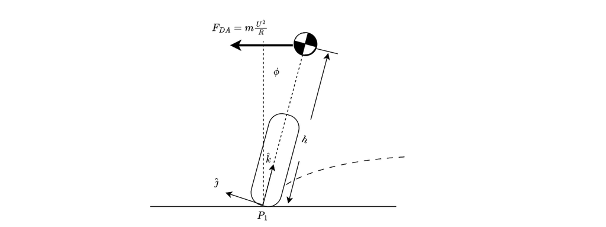

This "centrifugal" or D'Alembert force points towards the *outside* of the turn, and is located at a perpendicular distance $h\cos\phi$ from the ground. For a positive yaw rate (counterclockwise, from a positive steer angle), this force will produce a positive torque (clockwise when viewed from behind) about the roll axis. Substituting $\dot{\psi}=\frac{U}{R}$ into the familiar equation for the centrifugal force and multiplying by the moment arm yields our equation for the D'Alembert torque.

\begin{equation} \tau_{\phi,D} = mh\cos\phi \frac{U^2\sin\lambda}{b}\delta \end{equation}

Linearizing about $\phi=0$ yields:

\begin{equation} \tau_{\phi,D} = mh \frac{U^2\sin\lambda}{b}\delta \end{equation}

The second "non-conservative" torque applied about the roll axis, $\tau_{\phi,g}$, is a consequence of the trail $c$, or the distance between the steering axis's intersection with the ground and the front tire's contact point with the ground. When the vehicle steers, the trail causes the mass center of the bike to move laterally, since the contact between the front tire and the ground is assumed not to move (due to the no slip assumption). This is shown in the figure below.

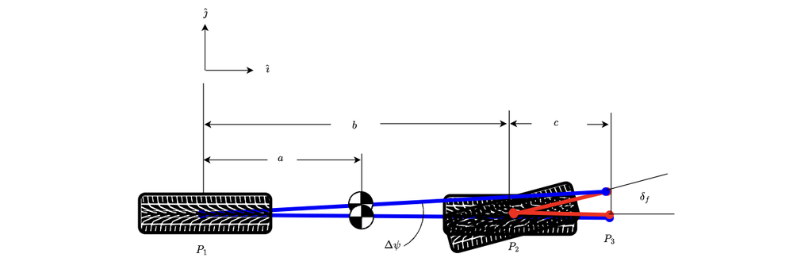

From the geometry presented in the figure above, we can see that that the change in yaw angle of the motorcycle's rigid bodies resulting from steer angle $\delta_f=\delta\sin\lambda$ is $\Delta \psi = \frac{c\sin\lambda}{b}\delta$. This means that if we assume that $\Delta \psi$ is small such that $\sin\Delta \psi \approx \Delta \psi$, then the lateral displacement of the rear frame's center of mass from the line $P_1P_2$ is approximately $a\Delta\psi = \frac{ac\sin\lambda}{b}\delta$.

This lateral offset is approximately perpendicular to the $\hat{\imath}$ direction, so the gravitational contribution to the torque $\vec{\tau}_{\phi}$ is simply the product of this perpendicular distance with the gravitational force acting on the vehicle's mass center. The torque is negative for a positive steering angle, and is in the $\hat{\imath}$ direction, as you can confirm using the right-hand rule:

\begin{equation} {\tau}_{\phi,g} = -\frac{gmac\sin\lambda}{b}\delta \end{equation}

You may be wondering why this torque is separate from the torque produced by gravity when the bike rolls. The reason is that the roll motion of the bike (and the steer motion, for the front frame) cause torques that are accounted for by the potential energy of the bike in the LaGrangian. The torque $\tau_{TF,g}$ is *independent* of how much potential energy the bike has, and is created by steer motion and gravity alone.

## Final Vehicle Model

Substituting Equation 17, with 19 and 20, into Equation 16 gives us our final vehicle model in differential equation form. note that because mass $m$ appears in every term, we can cancel it out. This is a consequence of our assumption that the vehicle's mass acts like a "point mass."

\begin{equation} \ddot{\phi} mh^2 -\frac{U\sin\lambda}{b} mah \dot{\delta} - mgh\phi = \frac{\sin\lambda}{b}\left(mhU^2-mg ac\right)\delta \end{equation}

Cancelling $m$ and solving for the roll acceleration, like you would have done in ES103 yields the following form:

\begin{equation} \ddot{\phi} = \frac{g}{h}\phi + \frac{\sin\lambda}{b}\left( \left(\frac{U^2}{h}-\frac{gac}{h^2}\right)\delta + \frac{aU}{h}\dot{\delta}\right) \end{equation}

So what use is this model? Well, we can use it if we add what's called a [*feedback controller*](https://alexanderallenbrown.github.io/ME480_FA22_Students/W04B_Control_PIDFundamentals/W04B_Control_PIDFundamentals.html). The idea is that we will make a "rule" about how the steer input $\delta$ is related to the bike's current roll $\phi$ and a **new input**, the **desired** roll angle $\phi_d$. That desired roll angle may just be 0 if our goal is to make the bike drive straight and stay upright, or we might want to decide to make the bike lean into a turn with, say, 10 degrees of lean.

The most common type of "rule" for feedback controllers operates on **error**, or the difference between the system's current output, and the **goal** or reference signal. This is shown in the figure below.

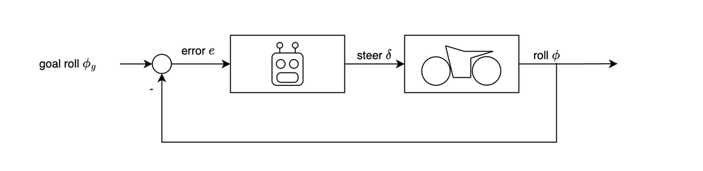

There are many types of "control laws" or "rules" that use error to "decide" how much input to give our system. In this case we need a rule that takes the difference between the roll we **want** and the roll we **have**, and somehow turns that into a steer angle $\delta$ for the motorcycle. If we choose a good rule, the bike will "steer into the fall" any time it starts to tip, which will allow it to remain stable.

The simplest type of "rule" for a feedback controller is called a **Proportional Control Law**. This says that the steer angle $\delta$ will be proportional to the error... so when there is a large error, the controller will steer a lot to correct it, and when there's a small error, the controller won't steer much at all. We can write this control law as an equation:

\begin{equation} \delta = K_p e = K_p \left(\phi_d - \phi \right) \end{equation}

We can substitute this equation into Equation 22, which changes our system's input from steering itself to the goal roll $\phi_d$.

\begin{equation} \ddot{\phi} = \frac{g}{h}\phi + \frac{\sin\lambda}{b}\left( \left(\frac{U^2}{h}-\frac{gac}{h^2}\right)K_p\left(\phi_d-\phi\right)+ \frac{aU}{h}K_p\left(\dot{\phi}_d-\dot{\phi}\right)\right) \end{equation}

Rearranging this equation to collect terms allows us to see it in a more familiar form:

\begin{equation} \ddot{\phi} = \left(\frac{g}{h} -K_p \frac{\sin\lambda}{b}\left(\frac{U^2}{h}-\frac{gac}{h^2}\right) \right) \phi - K_p\frac{aU\sin\lambda}{hb}\dot{\phi} + K_p \frac{\sin\lambda}{b}\left(\frac{U^2}{h}-\frac{gac}{h^2}\right) \phi_d + K_p\frac{aU\sin\lambda}{hb}\dot{\phi_d} \end{equation}

Now, there is a lot going on in this equation, but we can understand whether it is stable (whether the overall energy in the system decreases to 0 without inputs) by just setting the input $\phi_d$ to 0 and looking at the sign of each term.

\begin{equation} \ddot{\phi} = \left(\frac{g}{h} -K_p \frac{\sin\lambda}{b}\left(\frac{U^2}{h}-\frac{gac}{h^2}\right) \right) \phi - K_p\frac{aU\sin\lambda}{hb}\dot{\phi} \end{equation}

If we choose a "control gain" $K_p$ for our proportional control law such that the term multiplied by $\phi$ is negative, and the term multiplied by $\dot{\phi}$ is negative, then the system will reach a steady state of 0 if we start it with some initial roll angle and/or velocity. This is shown in the code block below. If you have Python3 equipped with the numpy and matplotlib libraries on your computer, try this script out for yourself and play around with $K_p$ to start understanding how changing its value changes the bike's behavior under closed loop control.

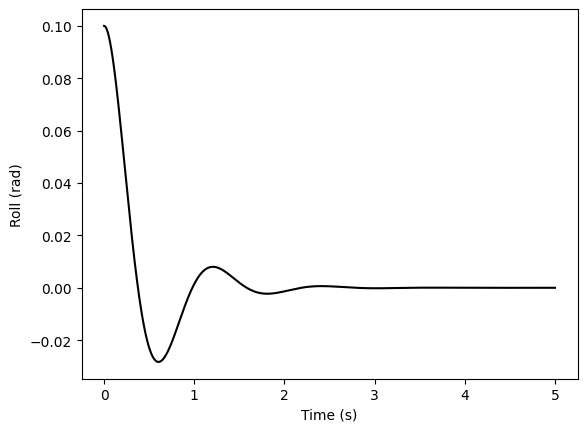

```python
from numpy import *
from matplotlib.pyplot import *

h = 1 # CG height
a = 0.5 #distance from rear axle to CG
b = 1.5 #wheelbase of a motocross bike is around this.
g = 9.81 #gravity
U = 5 #5 m/s is about 10 mph
c = 0.1 #about 4 inches of trail
lam = 1 #this is a reasonable number for the steer axis inclination on most motorcycles

Kp = 3 #this is our "control gain" for our proportional control law. We can use this to approximate a human rider's steering,
#or maybe it's a really crude model of the bike's self-steering properties. Or maybe it's a robot!

dt = .001 #timestep for simulation
t = arange(0,5,dt) #time vector
roll = zeros(size(t))
rollrate = zeros(size(t))
#set the bike to have some initial roll angle
roll[0] = 0.1

#euler integration
for k in range(1,len(t)):
    drollrate = (g/h - Kp*sin(lam)/b*(U**2/h - g*a*c/h**2))*roll[k-1] - Kp*(a*U*sin(lam)/(h*b))*rollrate[k-1]
    rollrate[k] = rollrate[k-1] + dt*drollrate
    roll[k] = roll[k-1] + dt*rollrate[k-1]

#plot results
figure
plot(t,roll,'k')
xlabel('Time (s)')
ylabel('Roll (rad)')
show()
```